# EDA

```python
import pandas as pd
```

```python
df =pd.read_csv(r"C:\Users\Anand Bharadwaj\OneDrive\Desktop\Final_Oyo_Rooms_cleaned.xls")
```

```python
df
```

|  | City | Hotel_Name | Location | Amenities | Clean_Price | Clean_Rating | Area | Has_AC | Has_Wifi | Has_TV | Price_Category |
| --- | --- | --- | --- | --- | --- | --- | --- | --- | --- | --- | --- |
| 0 | Hyderabad | Super Townhouse Narayanaguda Metro Station For... | Near Old MLA Quarters, Himayathnagar, Hyderabad | Parking facility Dining area Free Wifi + 14... | 1943.0 | 4.6 | Near Old Mla Quarters | 0 | 1 | 0 | Mid-range |
| 1 | Hyderabad | Hotel O A R International | Main Road Shamshabad, Hyderabad | Parking facility Dining area Free Wifi + 11... | 760.0 | 3.1 | Main Road Shamshabad | 0 | 1 | 0 | Budget |
| 2 | Hyderabad | Super Collection O Regal Near ISKON TEMPLE , A... | Nampally station road, Adj Lane Metro Foot Wea... | Parking facility Free Wifi Power backup + 1... | 1427.0 | 4.2 | Nampally Station Road | 0 | 1 | 0 | Mid-range |
| 3 | Hyderabad | Super Townhouse Kothapet Formerly Surabhi Elite | Kothapet, Hyderabad | Free Wifi Power backup Parking + 10 more | 1624.0 | 4.6 | Kothapet | 0 | 1 | 0 | Mid-range |
| 4 | Hyderabad | Super Townhouse Oak Madhapur Nera Regency | Madhapur, Hyderabad | Dining area Power backup Parking + 29 more | 1919.0 | 4.4 | Madhapur | 0 | 0 | 0 | Mid-range |
| ... | ... | ... | ... | ... | ... | ... | ... | ... | ... | ... | ... |
| 1468 | Chennai | Collection O Ramapuram Chennai | Near MIOT Hospital, Manapakkam, Chennai | AC TV | 776.0 | 3.9 | Near Miot Hospital | 1 | 0 | 1 | Budget |
| 1469 | Chennai | SPOT ON Golden Tree Guest House Near Ecr Beach | Near Bethel A.G. CHURCH, panaiyur, Chennai | TV Parking facility AC + 8 more | 366.0 | 4.2 | Near Bethel A.G. Church | 1 | 0 | 1 | Budget |
| 1470 | Chennai | Collection O Skywalk Hotel | Nelson manikandan road, Aminjikarai, Chennai | Parking facility Reception Free Wifi + 14 more | 952.0 | 4.2 | Nelson Manikandan Road | 0 | 1 | 0 | Budget |
| 1471 | Chennai | SPOT ON 67354 Hotel Murudis | Near Nehru Stadium, Chennai | Free Wifi Daily housekeeping AC + 1 more | 619.0 | 4.2 | Near Nehru Stadium | 1 | 1 | 0 | Budget |
| 1472 | Chennai | Capital O Bhagayam Suites Near Ags Cinemas T N... | Near Shree Shantinath Jain Temple, Chennai | AC AC TV + 1 more | 506.0 | 4.2 | Near Shree Shantinath Jain Temple | 1 | 0 | 1 | Budget |

1473 rows × 11 columns

```python
df.shape
```

```
(1473, 11)
```

```python
df.info()
```

```
<class 'pandas.core.frame.DataFrame'>
RangeIndex: 1473 entries, 0 to 1472
Data columns (total 11 columns):
 #   Column          Non-Null Count  Dtype
---  ------          --------------  -----
 0   City            1473 non-null   object
 1   Hotel_Name      1473 non-null   object
 2   Location        1473 non-null   object
 3   Amenities       1473 non-null   object
 4   Clean_Price     1473 non-null   float64
 5   Clean_Rating    1473 non-null   float64
 6   Area            1461 non-null   object
 7   Has_AC          1473 non-null   int64
 8   Has_Wifi        1473 non-null   int64
 9   Has_TV          1473 non-null   int64
 10  Price_Category  1473 non-null   object
dtypes: float64(2), int64(3), object(6)
memory usage: 126.7+ KB
```

```python
df.isnull().sum()
```

```
City               0
Hotel_Name         0
Location           0
Amenities          0
Clean_Price        0
Clean_Rating       0
Area              12
Has_AC             0
Has_Wifi           0
Has_TV             0
Price_Category     0
dtype: int64
```

# Univariate Analysis

```python
import pandas as pd
import numpy as np
import matplotlib.pyplot as plt
import seaborn as sns
import plotly.express as px
import warnings
warnings.filterwarnings('ignore')
```

```python
df['City'].value_counts()
```

```
City
Hyderabad    550
Delhi        287
Kolkata      274
Mumbai       152
Chennai      146
Goa           64
Name: count, dtype: int64
```

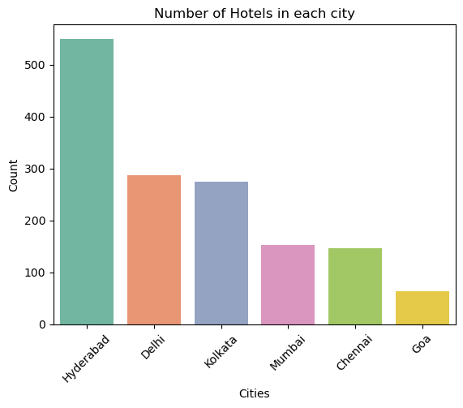

```python
city_counts = df['City'].value_counts()
sns.barplot(x=city_counts.index, y=city_counts.values, palette='Set2')
plt.title("Number of Hotels in each city")
plt.xlabel('Cities')
plt.ylabel('Count')
plt.xticks(rotation=45)
plt.show()
```

# Insights:

> More number of Hotels in Hyderabad which is around 550 out of 1473 hotels across these 6 cities.

> Less number of Hotels in Gao which is around 64 Out of 1473 hotels across these 6 cities.

> Delhi and Kolkata has equal number of hotels which is around 280.

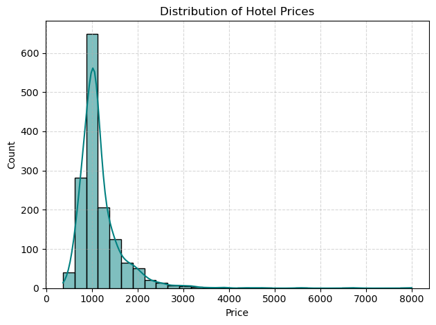

```python
sns.histplot(df['Clean_Price'], bins=30, kde=True,color='teal', edgecolor='black')
plt.title('Distribution of Hotel Prices')
plt.xlabel('Price')
plt.ylabel('Count')
plt.grid(True, linestyle='--', alpha=0.5)
plt.tight_layout()
plt.show()
```

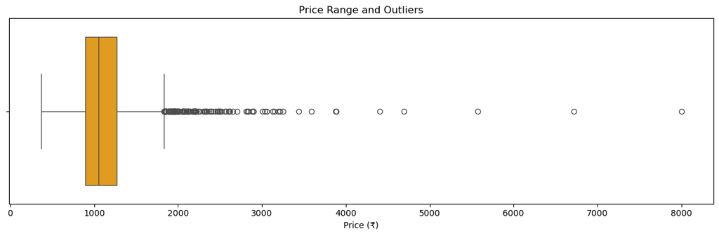

```python
plt.figure(figsize=(12, 4))
sns.boxplot(x=df['Clean_Price'], color='orange')
plt.title("Price Range and Outliers")
plt.xlabel("Price (₹)")
plt.tight_layout()
plt.show()
```

# Insights:

> The price distribution is right-skewed (positively skewed).This means the majority of OYO hotels are concentrated at the left side of the price scale, primarily between ₹500 and ₹2000.

> The long tail extending to the right shows a few premiumhotels that are significantly more expensive than the rest of the properties. The majority of prices between 500 to 2000 and above this are outliers

> In outliers the prices are distributed more between 2000-3500

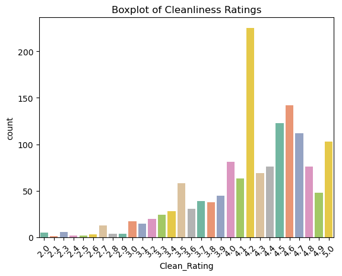

```python
sns.countplot(x=df['Clean_Rating'],palette='Set2')
plt.title('Boxplot of Cleanliness Ratings')
plt.xticks(rotation=45)
plt.show()
```

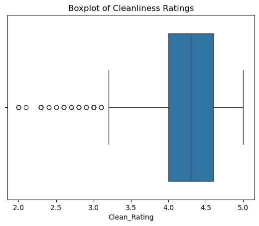

```python
sns.boxplot(x=df['Clean_Rating'])
plt.title('Boxplot of Cleanliness Ratings')
plt.show()
```

# Insights:

> The Majority ratings ranges from 4.0 to 4.5

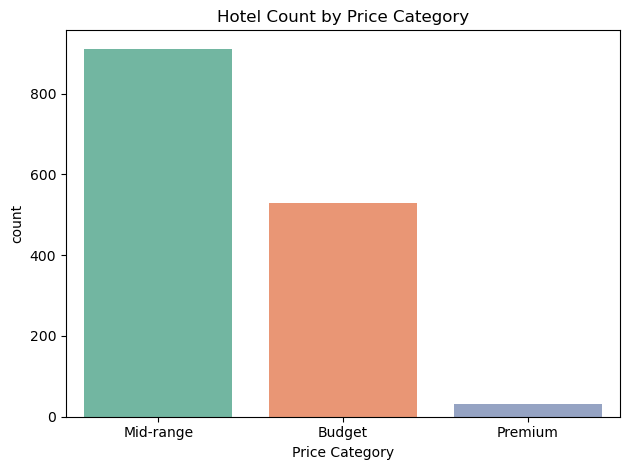

```python
sns.countplot(x='Price_Category', data=df,palette='Set2')
plt.title('Hotel Count by Price Category')
plt.xlabel("Price Category")
plt.tight_layout()
plt.show()
```

```python
df['Price_Category'].value_counts()
```

```
Price_Category
Mid-range    911
Budget       530
Premium       32
Name: count, dtype: int64
```

# Insights:

> With 911 hotels, the mid-range category clearly dominates the market.

> Fewer hotels 32 hotels are classified as premium

```python
df['Has_AC'].value_counts()
```

```
Has_AC
0    1369
1     104
Name: count, dtype: int64
```

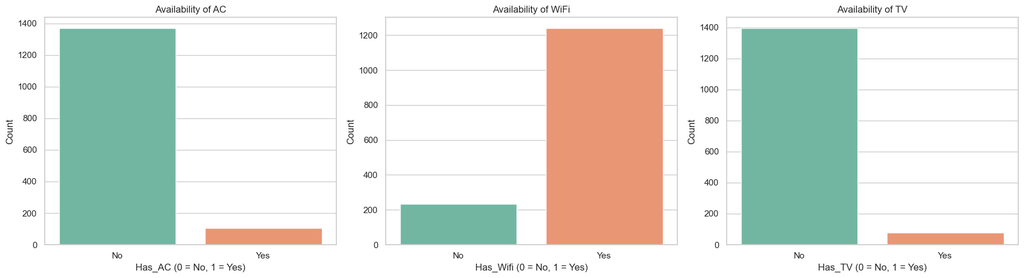

```python
sns.set(style="whitegrid")
plt.figure(figsize=(18, 5))


plt.subplot(1, 3, 1)
sns.countplot(x='Has_AC', data=df, palette='Set2')
plt.title('Availability of AC')
plt.xlabel('Has_AC (0 = No, 1 = Yes)')
plt.ylabel('Count')
plt.xticks([0, 1], ['No', 'Yes'])


plt.subplot(1, 3, 2)
sns.countplot(x='Has_Wifi', data=df, palette='Set2')
plt.title('Availability of WiFi')
plt.xlabel('Has_Wifi (0 = No, 1 = Yes)')
plt.ylabel('Count')
plt.xticks([0, 1], ['No', 'Yes'])

plt.subplot(1, 3, 3)
sns.countplot(x='Has_TV', data=df, palette='Set2')
plt.title('Availability of TV')
plt.xlabel('Has_TV (0 = No, 1 = Yes)')
plt.ylabel('Count')
plt.xticks([0, 1], ['No', 'Yes'])

plt.tight_layout()
plt.show()
```

# Insights:

> Hotels are with more number of non Ac rooms and less Ac rooms.

> Hotels have more availability of wifi

> Hotels have less availability of Tv

# Bivariate Analysis

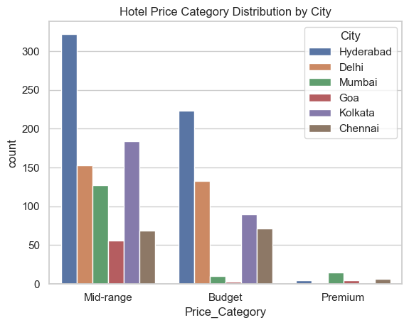

```python
sns.countplot(x='Price_Category', hue='City', data=df)
plt.title('Hotel Price Category Distribution by City')
plt.show()
```

# Insights:

> Hyderabad leads in Mid-range hotels, suggesting it’s a hotspot for value-conscious travelers who still expect decent amenities

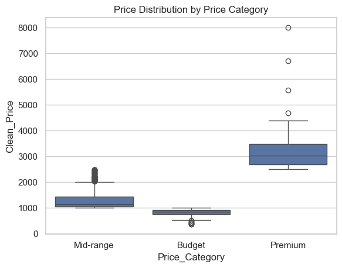

```python
sns.boxplot(x='Price_Category', y='Clean_Price', data=df)
plt.title('Price Distribution by Price Category')
plt.xlabel('Price_Category')
plt.ylabel('Clean_Price')
plt.show()
```

# Insights:

> Premium category has multiple outliers above ₹4000.

> Mid Range has multiple outliers above 2000.

# Multivaraite Analysis

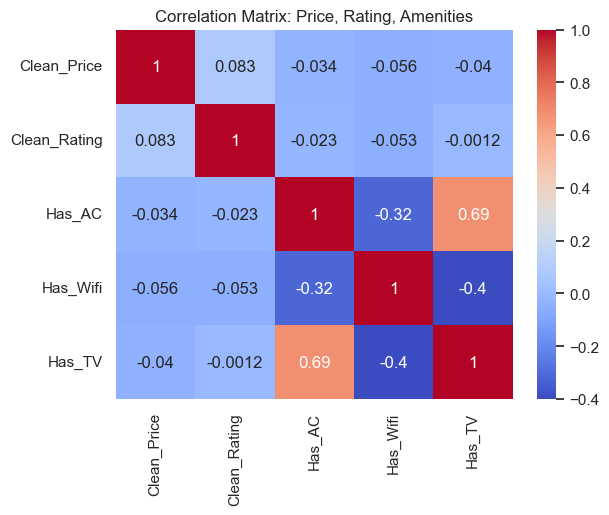

```python
corr = df[['Clean_Price', 'Clean_Rating', 'Has_AC', 'Has_Wifi', 'Has_TV']].corr()
sns.heatmap(corr, annot=True, cmap='coolwarm')
plt.title('Correlation Matrix: Price, Rating, Amenities')
plt.show()
```

# Insights:

> Clean_Price vs Clean_Rating → 0.083 Very weak positive correlation Suggests that higher prices don’t necessarily guarantee better cleanliness ratings. Guests may not perceive value purely through price

> Has_AC vs Has_TV → 0.69 Strong positive correlation Indicates that AC and TV often co-occur, likely bundled in mid-range or premium listings. Could be used as a proxy for comfort tier.

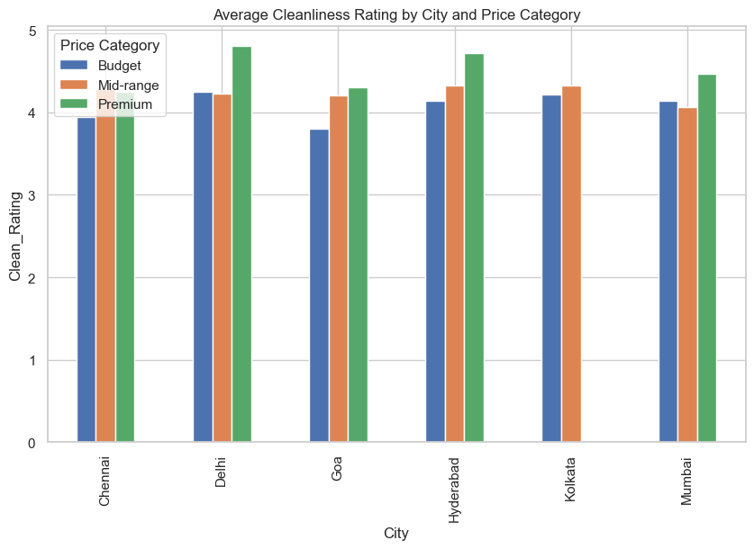

```python
grouped = df.groupby(['City', 'Price_Category'])['Clean_Rating'].mean().unstack()
grouped.plot(kind='bar', figsize=(10, 6))
plt.title('Average Cleanliness Rating by City and Price Category')
plt.ylabel('Clean_Rating')
plt.xlabel('City')
plt.legend(title='Price Category')
plt.show()
```

# Insights: